# EDA Code Notebook

Courtney Fitzgerald and Martinez Jean Claude

2024-10-22

## Introduction

#### Background

Opioids are a serious problem in the United States. Since the late 1990s the **opioid crisis has steadily worsened**. Many attribute the origins of this epidemic to the “Pain as the 5th Vital Sign” campaign and the FDA’s approval of the infamous Oxycontin drug. While the opioid crisis is considered a public health emergency, it is not uniformly harmful for everyone. Like many epidemics, **certain demographic groups are more at risk than others**.

#### Purpose

Understanding **how and why certain groups are most at risk of dying from opioids** is the first step to reducing the magnitude of this epidemic. This information will **enable targeted interventions**, whether they be at the community or policy level.

#### Objectives

This project **will examine some of the demographic factors, like race/ethnicity and gender, that contribute to and influence the harrowing opioid epidemic in the United States**. Through this demographic analysis, we will examine what cultural and societal factors lead to variations between certain groups.

#### Research Question

Specifically, we want to answer; *How do race, ethnicity, and gender contribute to variations in opioid-related mortalities?*

## The Data

#### Source

The data employed in this study is taken from the National Center for Health Statistics and specifically their National Vital Statistics System.

The data were gathered in 2019 and is based off of information taken from death certificates.The official information provided about the data set on the Center for Disease Control’s website is, “[Drug overdose death rates, by drug type, sex, age, race, and Hispanic origin: United States, selected years 1999-2018](https://data.cdc.gov/NCHS/Drug-overdose-death-rates-by-drug-type-sex-age-rac/95ax-ymtc/about_data)”.

We use this data set because it provides the demographic variables we need to explore between group comparisons, and it also provides an estimated rate of deaths per 100,000 for a given group. As such, the data’s appropriate combination of numerical and categorical variables will allow us to perform the appropriate statistical tests given our independent variables of race, ethnicity, and gender, and our single dependent variable of estimated death rate.

**Additional information:** The data in CSV file format can be found [here](https://www.cdc.gov/nchs/hus/contents2019.htm#Table-008).

| **Variables** | **Description** |
| --- | --- |
| Age | Ages of the observations but not specified in the dataset |
| Sex | Male or Female |
| Ethnicity | Hispanic non-specified race or Non-Hispanic |
| Race_Ethnicity | NH-Black or NH-White or NH-Native American or NH-AAPI or Hispanic non-specified race |
| Drug Type | Natural/Semi-synthetic Opioid or Methadone or Heroin or Synthetic Opioid |
| Year | 1999 - 2018 |
| Estimate | Rate of Overdose Deaths per 100,000 |

#### Data Limitations

While these data do include information on race, gender, and sex, they are not aggregated to our liking:

1. **When Hispanic ethnicity is identified, there is no race to accompany it.**
   - We cannot explicitly analyze the influence of ethnicity on a specific race, but rather on all races.
   - For this reason, we will create two separate variables relating to race/ethnicity:
     - One that includes race and ethnicity together.
     - Another that specifies Hispanic or not without any racial measure.
2. **Additionally, we only have information about sex, since these data are from death certificates.**
   - As such, we cannot consider the influence of other potentially relevant factors like one’s gender identity.
3. **We cannot examine how sexual orientation impacts opioid mortality.**
   - There is no measure of this either.

*It is important to note that these data are taken from death certificates, but do not include any potential identifying data.*

#### Subsetting the Data

The data was organized in a way that required a considerable amount of cleaning and subsetting in order to isolate the measures we intended to explore. Specifically, the demographic measures do not have their own variables, but rather are compiled into one variable, called **“STUB_LABEL”**.

We must use another variable called **“STUB_NAME”** and the corresponding numerical variables **“STUB_LABEL_NUM”** and **“STUB_NAME_NUM”** to relabel the required variables and subset them accordingly for our analysis.

```
- Each "STUB_NAME_NUM" number corresponds to categorical measure(s), for the sake of our analysis, we will focus on the "Sex and race and Hispanic origin" level of the "STUB_NAME" variable which corresponds to 5 in "STUB_NAME_NUM."

-A similar categorization system exists for specific groups with the "STUB_LABEL" and "STUB_LABEL_NUM" corresponding to "Female: Not Hispanic or Latino: White" and 5.7, respectively.

-The "STUB_LABEL_NUM" builds upon the "STUB_NAME_NUM" with a decimal number to denote a specific sex, ethnicity, and race.
```

*For this study we subset the data to exclusively include observations with specified sex, race, and ethnicity.*

## Methods

#### Overview

In order to evaluate how to best analyze the data we must familiarize ourselves with the variables and how they’re oriented.

This data set classifies drug overdose by type, and also takes into account estimations for the rate of overdose per 100,000 people for each group listed.

1. **Relabel the type of drug overdose for clarity**  
   This relies upon the existing **“PANEL”** and **“PANEL_NUM”** variables.
   - We will produce a table with these two variables so we can see which number correlates with a specific drug type.
2. **Subset the data to focus on the influence of race and sex on drug overdose**
   - Race and gender are under **“STUB_LABEL_NUM”**, so we will disaggregate it and rename it to make the data more readable and optimized for our statistical tests.
3. **End with five variables of interest**
   - **“ESTIMATE”**: Provides the average rate of deaths per 100,000 people.
   - **“Ethnicity”**: Identifies ethnicity of of our observations
   - **“Race”** and **“Sex”**: Show the racial identity and sex classification provided on the death certificate.
   - **“YEAR”**: Notes the year in which the deaths were registered.
   - **“Responsible_Drug”**: Identifies the drug responsible for the death as noted on the death certificate.

#### Loading in the Data and Packages

In order to answer our research question we need to **load the data and relevant packages** like tidyverse, ggplot2 and gridExtra that will allow us to complete the previously mentioned subsetting and the statistical tests required to compare the estimated death rates between certain groups.

```r
# Packages used
library(tidyverse)
```

```r
library(ggplot2)
library(gridExtra)
# Loading the dataset
drug <- read_csv("Renv/Data/drug_data.csv", show_col_types = F)
```

$~$

#### Examining and Cleaning the Data

Identifying how each drug overdoes type is categorized so we can relabel it.

```r
table(drug$PANEL_NUM, drug$PANEL)
```

```
##
##     All drug overdose deaths Drug overdose deaths involving any opioid
##   0                     1038                                         0
##   1                        0                                      1038
##   2                        0                                         0
##   3                        0                                         0
##   4                        0                                         0
##   5                        0                                         0
##
##     Drug overdose deaths involving heroin
##   0                                     0
##   1                                     0
##   2                                     0
##   3                                     0
##   4                                     0
```

[output cut: 25 more lines]

[output not shown]

```r
# Filtering to see the impact of the death rate estimate variation by racial/ethnic and sex groups based on type of drug causing overdose

drug_type <- drug %>%
  rename(Responsible_Drug = "PANEL_NUM") %>%
  mutate(
     Responsible_Drug = case_when(
      Responsible_Drug == 0 ~ "All Drug Types",
      Responsible_Drug == 1 ~ "Any Opioid",
      Responsible_Drug == 2 ~ "Natural/Semisynthetic Opioid",
      Responsible_Drug == 3 ~ "Methadone",
      Responsible_Drug == 4 ~ "Synthetic Opioid",
      Responsible_Drug == 5 ~ "Heroin",
      TRUE ~ "Unknown"
     ))

# Factor function to maintain the order of drug levels in visualization

drug_type$Responsible_Drug <- factor(drug_type$Responsible_Drug, levels =c("All Drug Types", "Any Opioid", "Natural/Semisynthetic Opioid", "Methadone", "Synthetic Opioid", "Heroin"))
```

**Production of tables to clarify the required demographic data, looking at the number that is populated by observations.**

**Next we will subset the data from the larger data set that are organized by race and sex**

```r
# Finding with single digit number represents the racial/sex level of the STUB_NAME variable

table(drug$STUB_NAME_NUM, drug$STUB_NAME)
```

```
##
##      Age  Sex Sex and age Sex and race Sex and race (single race)
##   0    0    0           0            0                          0
##   1 1080    0           0            0                          0
##   2    0  480           0            0                          0
##   3    0    0        2160            0                          0
##   4    0    0           0          960                         36
##   5    0    0           0            0                          0
##
##     Sex and race and Hispanic origin
##   0                                0
##   1                                0
##   2                                0
##   3                                0
##   4                                0
##   5                             1200
##
##     Sex and race and Hispanic origin (single race) Total
##   0                                              0   240
##   1                                              0     0
##   2                                              0     0
##   3                                              0     0
##   4                                              0     0
##   5                                             72     0
```

```r
# 5 is the number that corresponds to Race, Sex, and Ethnicity so we filtered on this to see which decimal number corresponds to each racial/gender group.
drug_exam <- drug_type %>%
  filter(STUB_NAME_NUM == 5)

# Produce a table to see which number corresponds to a specific racial/sex pairing (i.e Black Male)
table(drug_exam$STUB_LABEL_NUM, drug_exam$STUB_LABEL)
```

```
##
##        Female: Hispanic or Latino: All races
##   5.1                                      0
##   5.2                                      0
##   5.3                                      0
##   5.4                                      0
##   5.5                                      0
##   5.6                                    120
##   5.7                                      6
##   5.8                                      0
##   5.9                                      0
##   5.91                                     0
##   5.92                                     0
##   5.93                                     0
##
##        Female: Not Hispanic or Latino: American Indian or Alaska Native
##   5.1                                                                 0
##   5.2                                                                 0
##   5.3                                                                 0
##   5.4                                                                 0
##   5.5                                                                 0
##   5.6                                                                 0
##   5.7                                                                 0
##   5.8                                                                 0
##   5.9                                                               120
##   5.91                                                                6
##   5.92                                                                0
##   5.93                                                                0
##
##        Female: Not Hispanic or Latino: Asian
##   5.1                                      0
##   5.2                                      0
##   5.3                                      0
##   5.4                                      0
##   5.5                                      0
##   5.6                                      0
##   5.7                                      0
##   5.8                                      0
##   5.9                                      0
##   5.91                                     0
```

[output cut: 141 more lines]

```
##   5.93                                                                       0
##
##        Male: Not Hispanic or Latino: White
##   5.1                                    0
##   5.2                                  126
##   5.3                                    0
##   5.4                                    0
##   5.5                                    0
##   5.6                                    0
##   5.7                                    0
##   5.8                                    0
##   5.9                                    0
##   5.91                                   0
##   5.92                                   0
##   5.93                                   0
```

| **Number** | **Description** |
| --- | --- |
| 5.1 | Hispanic Males, Unspecified Race |
| 5.2 | Non-Hispanic White Males |
| 5.3 | Non-Hispanic Black Males |
| 5.4 | Non-Hispanic Native American Males |
| 5.5 | Non-Hispanic Asian American Pacific Islander Males |
| 5.6 | Hispanic Females, Unspecified Race |
| 5.7 | Non-Hispanic White Females |
| 5.8 | Non-Hispanic Black Females |
| 5.9 | Non-Hispanic Native American Females |
| 5.91 | Non-Hispanic Asian American Pacific Islander Females |

This allows for the **creation of a new variable** that explicitly states that states these race/sex pairings and produce a subset that focus on this new variable.

The **subset disaggregates race and sex** so that we can perform a *2-way ANOVA* to see if these two variables are statistically *significant predictors for drug overdose mortality*.

```r
drug_RES <- drug_type %>%
  filter(STUB_NAME_NUM == 5) %>%
  rename(Race_Ethnicity = "STUB_LABEL_NUM") %>%
  mutate(
     Race_Ethnicity = case_when(
     Race_Ethnicity == 5.1 ~ "Hispanic, Unspecified Race",
      Race_Ethnicity == 5.2 ~ "NH White",
      Race_Ethnicity == 5.3 ~ "NH Black",
      Race_Ethnicity == 5.4 ~ "NH Native American",
      Race_Ethnicity == 5.5 ~ "NH AAPI",
      Race_Ethnicity == 5.6 ~ "Hispanic, Unspecified Race",
      Race_Ethnicity == 5.7 ~ "NH White",
      Race_Ethnicity == 5.8 ~ "NH Black",
      Race_Ethnicity == 5.9 ~ "NH Native American",
      Race_Ethnicity == 5.91 ~ "NH AAPI",
      TRUE ~ "Unknown"
    )) %>%
   mutate(
   Ethnicity = case_when(
      grepl("Black", Race_Ethnicity) ~ "Non-Hispanic",
      grepl("White", Race_Ethnicity) ~ "Non-Hispanic",
      grepl("Native American", Race_Ethnicity) ~ "Non-Hispanic",
      grepl("AAPI", Race_Ethnicity) ~ "Non-Hispanic",
      grepl("Hispanic", Race_Ethnicity) ~ "Hispanic, Unspecified Race",
      TRUE ~ "Unknown"
    )) %>%
  mutate(
    Sex = case_when(
      grepl("Female", STUB_LABEL) ~ "Female",
      grepl("Male", STUB_LABEL) ~ "Male",
      TRUE ~ "Unknown"))

##Further cleaning data to remove NAs, Unknowns, and generalized drug types
drug_RES$FLAG <- NULL
drug_RES <- drug_RES %>%
  filter(!grepl("Unknown", Race_Ethnicity)) %>%
  filter(!grepl("Any", Responsible_Drug)) %>%
  filter(!grepl("All", Responsible_Drug)) %>%
  na.omit


##Disaggregating by Sex for Central Measures and Visualization
drug_Fem <- drug_RES %>%
  filter(Sex == "Female")

drug_Male <- drug_RES %>%
  filter(Sex == "Male")
```

## Visualizing the Distribution

#### All Racial and Sex Identity Groups, for all Drug Overdose Types, from 1999 - 2018

We produced this visualization initially to get an **idea of the increase of drug mortality over around 20 years**. This time period is especially relevant as the CDC declares that this time range represents the “[Opioid Epidemic](https://www.cdc.gov/museum/pdf/cdcm-pha-stem-uncovering-the-opioid-epidemic-lesson.pdf)”and many of the drugs identified in this data set are classified as some form of an opioid. This information is also helpful in highlighting the variation in mortality by race/sex pairings.

$~$

##### *Plots Comparing Men and Women Across Race/Ethnic Groups*

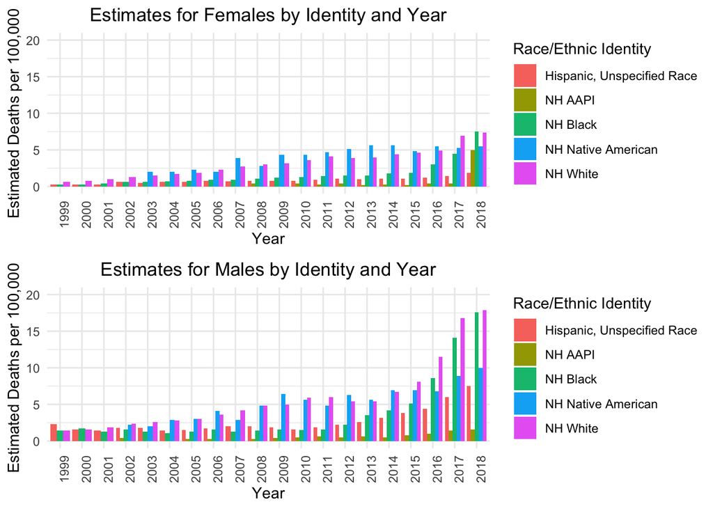

**Importance:** These data tell us a lot regarding the different observations witnessed. The distributions provide us with essential information about certain sex/race pairings, as well as the general trends of these groups over time. Such information is helpful as we perform more “narrow” visualizations and analysis.

$~$

##### *Distribution of Sex By Estimate*

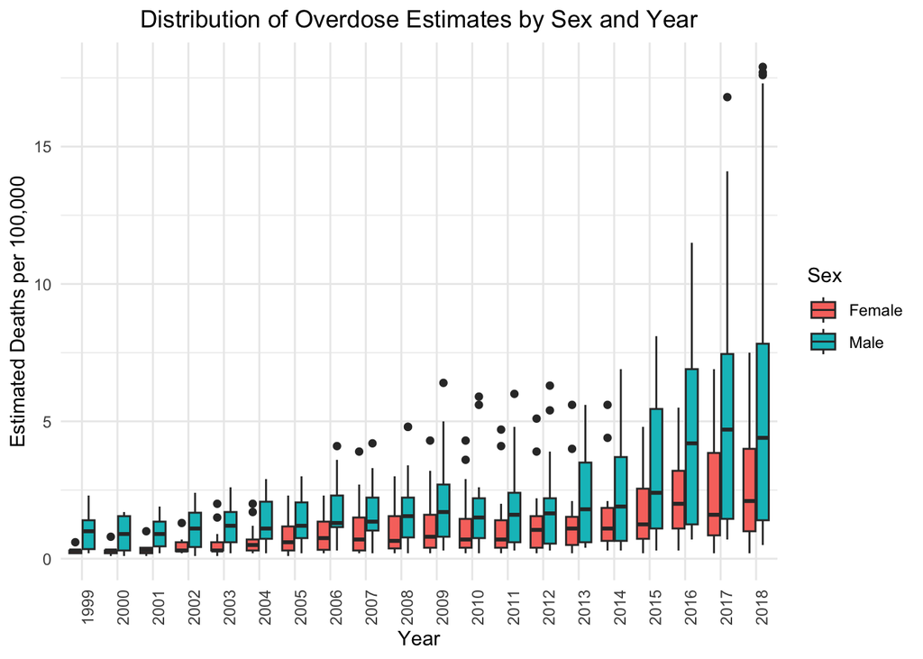

**Summary:** The graph shows that a common trend for both female and male is that *as the year increased the number of drug overdose increased.* While it was a subtle increase for females, the males saw a larger rise in drug overdose deaths.

The *differences in the rate of increase are visible from the continued distance in the median bar between females and males as time goes on*. We can verify this with additional central tendency measures.

$~$

##### *Distribution of Ethnicity on Overdose Estimate by Drug Type*

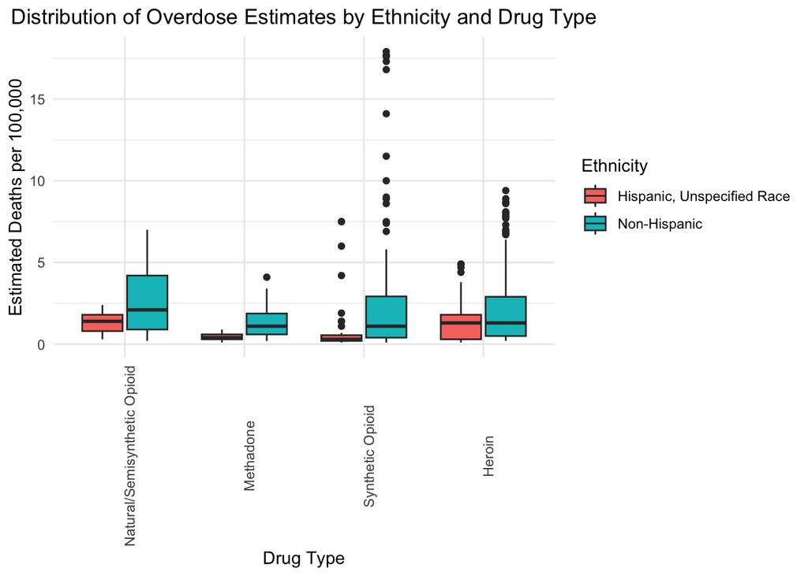

```r
year_Ethnicity <- ggplot(drug_RES, aes(x = factor(Responsible_Drug), y = ESTIMATE, fill = Ethnicity)) +
  geom_boxplot(na.rm = TRUE) +
  labs(title = "Distribution of Overdose Estimates by Ethnicity and Drug Type",
       x = "Drug Type",
       y = "Estimated Deaths per 100,000") +
  theme_minimal() + theme(axis.text.x = element_text(angle = 90)) + theme(plot.title = element_text(hjust = 0.5))

year_Ethnicity
```

**Summary**: Based on the graph we can see that in terms of **non-Hispanic, their drug overdose mortality is highly influenced by synthetic opioids**. Even though across the different drug types they tend to be mopre likely to experience drug overdose.

$~$

##### *Distribution of Overdose Estimates by Drug type and Race/Ethnic Identity*

We wanted to see the *distribution of the different responsible drugs responsible for the overdose among the different race and genders to see which type of drug is more prevalent*.

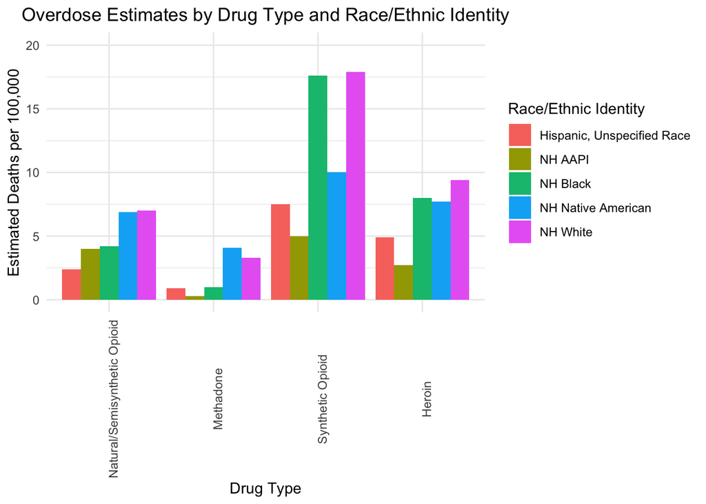

**Summary:** The graph shows that among the drug types, **synthetic opioids appear to be one of the leading causes of death** by drug overdose. Specifically for Non-Hispanic White and Non-Hispanic black as they have a higher mortality estimate compared to other Race/Ethnic identities.

We can also see that **methadone has the lowest rates for every group** when averaging rates from 1999-2018.This is likely because methadone is typically **given out at rehabilitation clinics as way to mitigate withdrawal symptoms** for drug users trying to **decrease or eliminate their opioid consumption**. Since clinics typically dispense this drug, it is in a more controlled environment with a measure dose which is likely why we see lower rates.

$~$

##### *Distribution of Overdose Estimates by Drug type and Race/Ethnic Identity Among Men and Women*

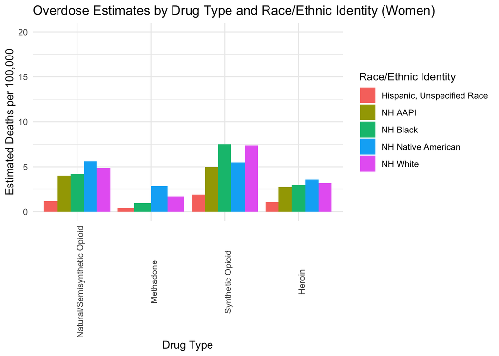

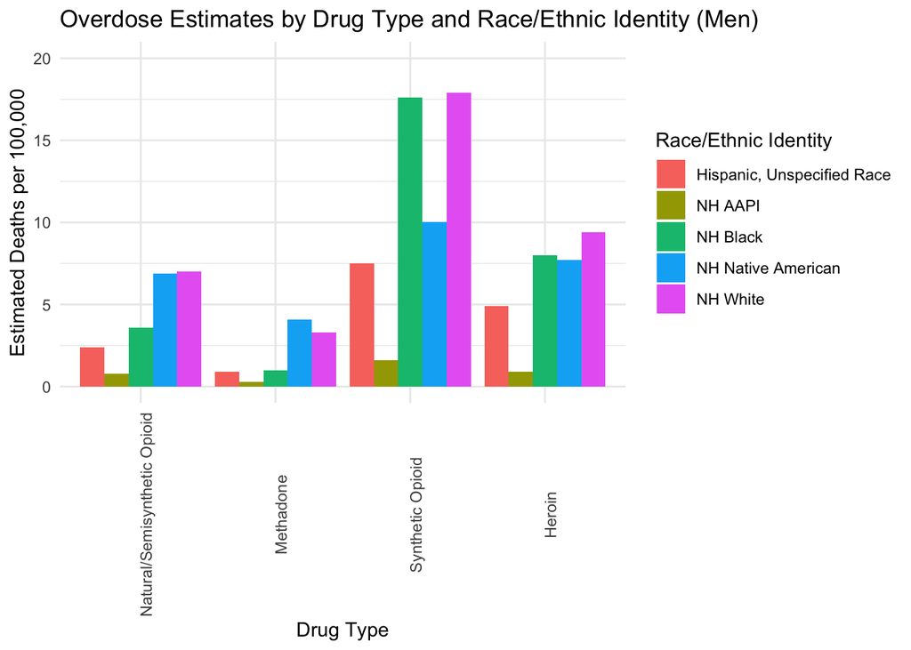

**Summary**: The **synthetic opioid has the highest estimate out of all of the categories**.Fentanyl is a highly potent and potentially lethal drug that is classified as a synthetic opioid. Although we cannot conclude based upon the language used in this data set, **fentanyl is likely the reason why this categories’ estimates are higher**. It is important to note that fentanyl is 50 times more potent than heroin and 100 times more potent than morphine, meaning it is more lethal in smaller quantities.

$~$